# Michael Hornsby EDRM 878 Assignment 4

Import and tidy data:

```r
data(blocks)

blocks$Trial <- as.factor(blocks$Trial)
blocks$Shape <- as.factor(blocks$Shape)

summary(blocks)
```

```
     Child        Number           Time        Trial       Shape         Age
 A      : 4   Min.   : 3.00   Min.   :  6.00   1:50   Cube    :50   Min.   :2.420
 B      : 4   1st Qu.: 5.00   1st Qu.: 14.40   2:50   Cylinder:50   1st Qu.:3.670
 C      : 4   Median : 6.00   Median : 20.20                        Median :4.000
 D      : 4   Mean   : 6.82   Mean   : 29.59                        Mean   :4.026
 E      : 4   3rd Qu.: 8.00   3rd Qu.: 35.00                        3rd Qu.:4.580
 F      : 4   Max.   :13.00   Max.   :178.00                        Max.   :5.080
 (Other):76
```

My 6.10 glm:

```r
summary(glm(Number ~ Age, family = poisson(link = log), data = blocks))
```

```
Call:
glm(formula = Number ~ Age, family = poisson(link = log), data = blocks)

Deviance Residuals:
    Min       1Q   Median       3Q      Max
-1.4977  -0.6542  -0.1984   0.4714   1.8155

Coefficients:
            Estimate Std. Error z value Pr(>|z|)
(Intercept)   1.3447     0.2223   6.048 1.47e-09 ***
Age           0.1415     0.0534   2.650  0.00805 **
---
Signif. codes:  0 ‘***’ 0.001 ‘**’ 0.01 ‘*’ 0.05 ‘.’ 0.1 ‘ ’ 1

(Dispersion parameter for poisson family taken to be 1)

    Null deviance: 69.429  on 99  degrees of freedom
Residual deviance: 62.244  on 98  degrees of freedom
AIC: 439.64

Number of Fisher Scoring iterations: 4
```

Problem 7.4

The Wald test for age (same as above):

```r
summary(glm(Number ~ Age, family = poisson(link = log), data = blocks))
```

```
Call:
glm(formula = Number ~ Age, family = poisson(link = log), data = blocks)

Deviance Residuals:
    Min       1Q   Median       3Q      Max
-1.4977  -0.6542  -0.1984   0.4714   1.8155

Coefficients:
            Estimate Std. Error z value Pr(>|z|)
(Intercept)   1.3447     0.2223   6.048 1.47e-09 ***
Age           0.1415     0.0534   2.650  0.00805 **
---
Signif. codes:  0 ‘***’ 0.001 ‘**’ 0.01 ‘*’ 0.05 ‘.’ 0.1 ‘ ’ 1

(Dispersion parameter for poisson family taken to be 1)

    Null deviance: 69.429  on 99  degrees of freedom
Residual deviance: 62.244  on 98  degrees of freedom
AIC: 439.64

Number of Fisher Scoring iterations: 4
```

This does suggest age makes a significant predictor of the number of blocks when using the Poisson regression for the Number of Blocks response variable.

The score test:

```r
blocks.m0 <- glm(Number ~ 1, data = blocks, family = poisson(link = "log"))
z.stat <- glm.scoretest(blocks.m0, blocks$Age)
p.val <- 2 * pnorm(abs(z.stat), lower.tail = FALSE)
round(c(score.stat = z.stat, P = p.val), 4)
```

```
score.stat          P
    2.6523     0.0080
```

The score test also suggests age makes for a significant predictor with just about the same p-value.

The likelihood ratio test:

```r
fit <- glm(Number ~ Age, data = blocks, family = poisson(link = "log"))
as.data.frame(anova(fit, test = "Chisq"))
```

|  | Df | Deviance | Resid. Df | Resid. Dev | Pr(>Chi) |
| --- | --- | --- | --- | --- | --- |
| NULL | NA | NA | 99 | 69.42922 | NA |
| Age | 1 | 7.185388 | 98 | 62.24384 | 0.007349966 |

The likelihood ratio test p-value is similar as well.

The results from all 3 tests suggest the same conclusion. All 3 tests results in p-values very close to 0.008, which is significant at any reasonable alpha level. Thus, all 3 tests conclude that age is a significant predictor for the number of blocks when using a poisson distribution and a log link for the distribution of the number of blocks response.

```r
min(blocks$Number)
```

```
[1] 3
```

The saddlepoint approximation is sufficiently accureate when the min(yi) is greater than or equal to 3 when using the poisson distribution. Thus, the saddlepoint approximation should be sufficiently accurate as our min(yi) = 3.

The Central Limit Theorem is sufficiently accurate when the min(yi) is greater than or equal to 5 when using the poisson distribution. Thus, we cannot expect the Central Limit Theorem to be sufficiently accurate as our min(yi) = 3.

```r
wald.fit <- glm(Number ~ Age, family = poisson(link = log), data = blocks)
printCoefmat(coef(summary(wald.fit)))
```

```
            Estimate Std. Error z value Pr(>|z|)
(Intercept)  1.34470    0.22235  6.0476 1.47e-09 ***
Age          0.14151    0.05340  2.6500  0.00805 **
---
Signif. codes:  0 ‘***’ 0.001 ‘**’ 0.01 ‘*’ 0.05 ‘.’ 0.1 ‘ ’ 1
```

```r
confint(wald.fit)
```

```
                2.5 %    97.5 %
(Intercept) 0.9024058 1.7742235
Age         0.0377308 0.2471074
```

Plot of relationship:

```r
plot(Number ~ Age, data = blocks)

abline(a = exp(1.34470), b = exp(0.14151))
```

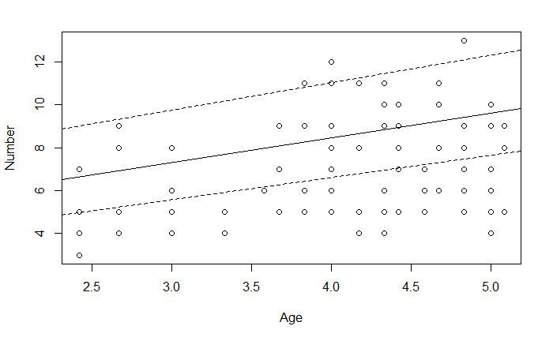

```r
abline(a = exp(0.9024058), b = exp(0.0377308), lty = 2)
abline(a = exp(1.7742235), b = exp(0.2471074), lty = 2)
```

Problem 8.11:

Once again, the model:

```r
my.model <- glm(Number ~ Age, family = poisson(link = log), data = blocks)
```

Let’s see if I’ve chosen the right EDM, my residuals should have a normal distribution:

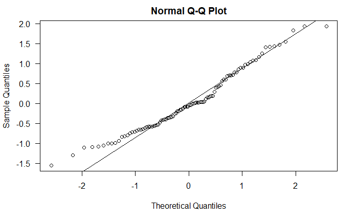

```r
qr.my.model <- qresid(my.model)
qqnorm(qr.my.model, las = 1)
qqline(qr.my.model)
```

This looks ok, not spectacular. I would think it shows that the tails are a little light, but I don’t think this would invalidate the model.

Check for outliers:

```r
rs <- cbind(rD = resid(my.model),
            "r'D" = rstandard(my.model),
            "r''" = rstudent(my.model),
            rQ = qresid(my.model))

head(rs)
```

```
         rD       r'D       r''        rQ
1 1.2214582 1.2324376 1.2340715 1.3775813
2 0.4246714 0.4310398 0.4313605 0.6502137
3 0.3035340 0.3054627 0.3055353 0.2448180
4 0.6917297 0.6957191 0.6960639 0.8004774
5 1.0321228 1.0380754 1.0388433 1.1692750
6 1.7766175 1.7970773 1.8014537 1.9710928
```

```r
apply(abs(rs), 2, max)
```

```
      rD      r'D      r''       rQ
1.815544 1.824790 1.826942 1.971093
```

These maximum residuals look pretty good I would say, nothing extreme.

Let’s check for influential observations:

```r
im <- influence.measures(my.model)
names(im)
```

```
[1] "infmat" "is.inf" "call"
```

```r
im$infmat <- round(im$infmat, 3)
head(im$infmat)
```

```
  dfb.1_ dfb.Age dffit cov.r cook.d   hat
1 -0.100   0.130 0.209 0.989  0.016 0.018
2 -0.062   0.073 0.094 1.045  0.003 0.029
3 -0.010   0.017 0.043 1.031  0.001 0.013
4 -0.013   0.028 0.094 1.017  0.003 0.011
5 -0.019   0.043 0.141 0.997  0.007 0.011
6 -0.204   0.250 0.351 0.939  0.045 0.023
```

```r
colSums(im$is.inf)
```

```
 dfb.1_ dfb.Age   dffit   cov.r  cook.d     hat
      0       0       0       7       0       0
```

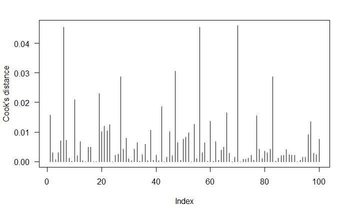

```r
my.model.cd <- cooks.distance(my.model)

plot(my.model.cd,
     type = "h",
     ylab = "Cook's distance",
     las = 1)
```

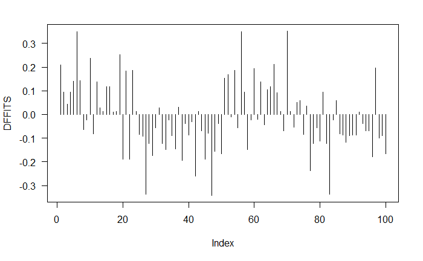

```r
plot(dffits(my.model),
     type = "h",
     las = 1,
     ylab = "DFFITS")
```

```r
infl <- which.max(my.model.cd)
infl
```

```
70
70
```

```r
my.model.cd[infl]
```

```
        70
0.04597928
```

All of these values look well within reasonable bounds. I don’t think I’m concerned about any of these Cook’s distance values or DFFITS.